# SRT411 Assignment 0

## ToDo 12

Make a graph with on the x-axis: today, Sinterklaas 2017 and your next birthday and on the y-axis the number of presents you expect on each of these days. Tip: make two vectors first.

ToDo12.R

```r
#ToDo12.R
x=strptime(c("20170130","20171206","20170812"),format="%Y%m%d")
y=c(0,10,5)
plot(x,y,xlab="Date",ylab="Number of Presents Expected",
     lwd=2,pch=8,cex=1.5,col=c("green","red"))
```

```r
source("ToDo12.R")
```

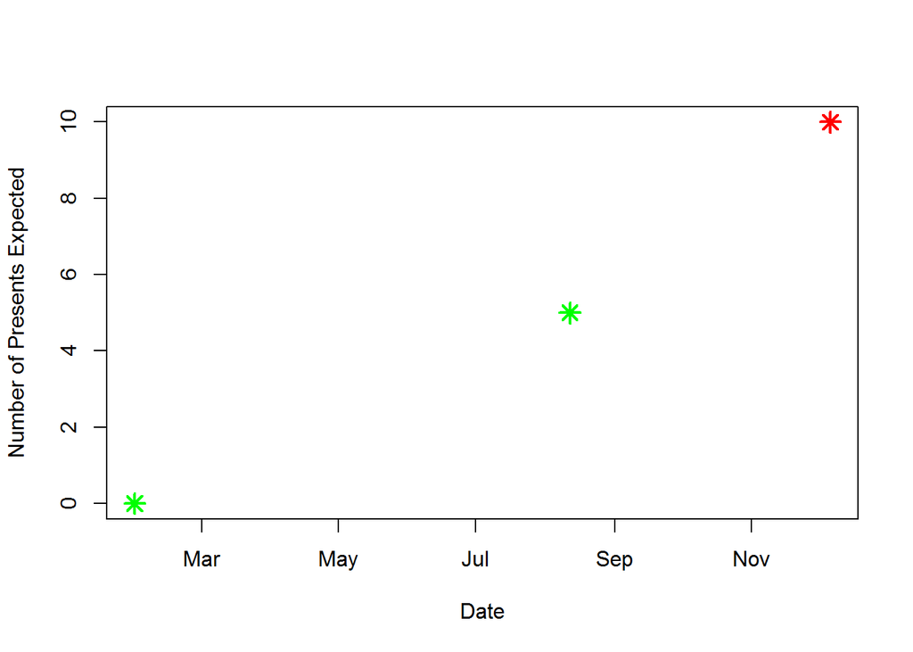

## ToDo 13

Make a vector from 1 to 100. Make a for-loop which runs through the whole vector. Multiply the elements which are smaller than 5 and larger than 90 with 10 and the other elements with 0.1.

```r
v=(1:100)
m=c()
for(i in 1:length(v)){
  if(i<5 | i>90){
    m[i]=v[i]*10
  }else{
    m[i]=v[i]*0.1
  }
}
m
```

```
##   [1]   10.0   20.0   30.0   40.0    0.5    0.6    0.7    0.8    0.9    1.0
##  [11]    1.1    1.2    1.3    1.4    1.5    1.6    1.7    1.8    1.9    2.0
##  [21]    2.1    2.2    2.3    2.4    2.5    2.6    2.7    2.8    2.9    3.0
##  [31]    3.1    3.2    3.3    3.4    3.5    3.6    3.7    3.8    3.9    4.0
##  [41]    4.1    4.2    4.3    4.4    4.5    4.6    4.7    4.8    4.9    5.0
##  [51]    5.1    5.2    5.3    5.4    5.5    5.6    5.7    5.8    5.9    6.0
##  [61]    6.1    6.2    6.3    6.4    6.5    6.6    6.7    6.8    6.9    7.0
##  [71]    7.1    7.2    7.3    7.4    7.5    7.6    7.7    7.8    7.9    8.0
##  [81]    8.1    8.2    8.3    8.4    8.5    8.6    8.7    8.8    8.9    9.0
##  [91]  910.0  920.0  930.0  940.0  950.0  960.0  970.0  980.0  990.0 1000.0
```

## ToDo 14

Write a function for the previous ToDo, so that you can feed it any vector you like (as argument). Use a for-loop in the function to do the computation with each element. Use the standard R function length in the specification of the counter.

```r
fun1=function(arg1,arg2){
  v=(1:100)
  m=c()
  for(i in v){
    if(i<5 | i>90){
      m[i]=v[i]*arg1
    }else{
      m[i]=v[i]*arg2
    }
  }
  m
}
fun1(arg1=0,arg2=0.5)
```

```
##   [1]  0.0  0.0  0.0  0.0  2.5  3.0  3.5  4.0  4.5  5.0  5.5  6.0  6.5  7.0
##  [15]  7.5  8.0  8.5  9.0  9.5 10.0 10.5 11.0 11.5 12.0 12.5 13.0 13.5 14.0
##  [29] 14.5 15.0 15.5 16.0 16.5 17.0 17.5 18.0 18.5 19.0 19.5 20.0 20.5 21.0
##  [43] 21.5 22.0 22.5 23.0 23.5 24.0 24.5 25.0 25.5 26.0 26.5 27.0 27.5 28.0
##  [57] 28.5 29.0 29.5 30.0 30.5 31.0 31.5 32.0 32.5 33.0 33.5 34.0 34.5 35.0
##  [71] 35.5 36.0 36.5 37.0 37.5 38.0 38.5 39.0 39.5 40.0 40.5 41.0 41.5 42.0
##  [85] 42.5 43.0 43.5 44.0 44.5 45.0  0.0  0.0  0.0  0.0  0.0  0.0  0.0  0.0
##  [99]  0.0  0.0
```

## Additional

Prove the last foot note true.

Actually, people often use more for-loops than necessary. The ToDo above can be done more easily and quickly without a for-loop but with regular vector computations.

```r
fun1=function(arg1,arg2){
  a=(1:4)
  b=(5:90)
  c=(91:100)
  m=c(a*arg1,b*arg2,c*arg1)
  m
}
fun1(arg1=0.5,arg2=0)
```

```
##   [1]  0.5  1.0  1.5  2.0  0.0  0.0  0.0  0.0  0.0  0.0  0.0  0.0  0.0  0.0
##  [15]  0.0  0.0  0.0  0.0  0.0  0.0  0.0  0.0  0.0  0.0  0.0  0.0  0.0  0.0
##  [29]  0.0  0.0  0.0  0.0  0.0  0.0  0.0  0.0  0.0  0.0  0.0  0.0  0.0  0.0
##  [43]  0.0  0.0  0.0  0.0  0.0  0.0  0.0  0.0  0.0  0.0  0.0  0.0  0.0  0.0
##  [57]  0.0  0.0  0.0  0.0  0.0  0.0  0.0  0.0  0.0  0.0  0.0  0.0  0.0  0.0
##  [71]  0.0  0.0  0.0  0.0  0.0  0.0  0.0  0.0  0.0  0.0  0.0  0.0  0.0  0.0
##  [85]  0.0  0.0  0.0  0.0  0.0  0.0 45.5 46.0 46.5 47.0 47.5 48.0 48.5 49.0
##  [99] 49.5 50.0
```

## Acknowledgements

https://nicercode.github.io/guides/reports/

http://rmarkdown.rstudio.com/

https://www.rstudio.com/wp-content/uploads/2016/03/rmarkdown-cheatsheet-2.0.pdf

https://www.r-bloggers.com/how-to-write-the-first-for-loop-in-r/

https://stackoverflow.com/questions/24058054/standard-deviation-on-dataframe-does-not-work

https://stat.ethz.ch/pipermail/r-announce/2013/000561.html

https://egret.psychol.cam.ac.uk/statistics/R/enteringdata.html

http://www.r-tutor.com/r-introduction/basic-data-types/integer

https://en.wikipedia.org/wiki/NaN

https://wiki.mobilizingcs.org/rstudio/plots

https://rstudio-pubs-static.s3.amazonaws.com/7953_4e3efd5b9415444ca065b1167862c349.html

http://paleocave.sciencesortof.com/2013/03/writing-a-for-loop-in-r/